# Version 1.3.2

## General

- `bitmart` has updated their futures API. The backend have been updated accordingly.
- Unit-tests have been updated and now all `get_quote()`-functions are being tested for equality in passed and inferred interval.

## Read and Write `xts`-objects

- `read_xts()` and `write_xts()` reads and stores `xts`-objects. These functions are essentially just wrappers of `zoo::read.zoo()` and `zoo::write.zoo()`. Thank you @gokberkcan7 for the suggestion.

### Charting

- The `chart()`-function are now exported as `.svg`-images in 4k resolution via the `modebar`.
- The `chart()`-function are now more interactive and supports drawing lines and rectangles via the `modebar`. It is also possible to interactively change the `title` and `subtitle` by double clicking these (Thank you @andreltr for the suggestion. See [Discussion](https://github.com/serkor1/cryptoQuotes/discussions/19)).
- The `chart()`-function now has a new option `static` that is equal to `FALSE` by default. If `FALSE` the chart can be edited, annotated and explored interactively.
- The `chart()`-function now has a new option `palette` that is set to “hawaii” by default. See `hcl.pals()` for accepted values.
- The `chart()`-function now has a new option `scale` that is set to 1 by default. Scales all fonts on the chart.
- The `chart()`-function now has a new option `width` that is set to 0.9 by default. Sets the overall `linewidth` of the chart. (Thank you @andreltr for the suggestion. See [Discussion](https://github.com/serkor1/cryptoQuotes/discussions/30))

**Static set to FALSE (Default Palette)**

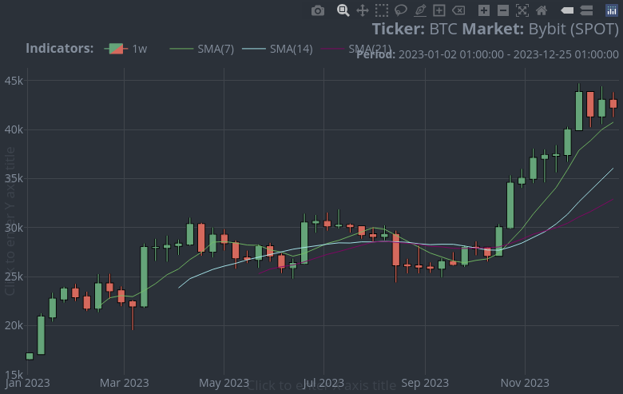

```r
# static = FALSE
chart(
  ticker  = BTC,
  main    = kline(),
    indicator = line(
    sma(n = 7),
    sma(n = 14),
    sma(n = 21)
  ),
  options = list(
    static = FALSE,
    palette = "hawaii"
  )
)
```

**Static set to TRUE (“Set 3” palette)**

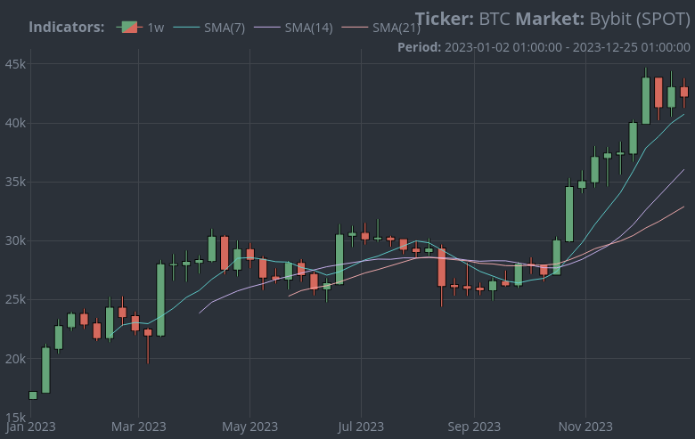

```r
# static = TRUE
chart(
  ticker  = BTC,
  main    = kline(),
  indicator = line(
    sma(n = 7),
    sma(n = 14),
    sma(n = 21)
  ),
  options = list(
    static  = TRUE,
    palette = "Set 3"
  )
)
```

### Supported Exchanges (Issue [#14](https://github.com/serkor1/cryptoQuotes/issues/14))

[{cryptoQuotes}](https://serkor1.github.io/cryptoQuotes/) now supports the following exchanges:

- Crypto.com
- Huobi
- MEXC

## Bugfixes

### Charting

- Fixed a bug in the `chart()`-function where a warning would be given if called using namespace qualified function calls (Issue [#13](https://github.com/serkor1/cryptoQuotes/issues/13))
- Fixed a bug in the `chart()`-function where a `legend` wouldn’t show unless a main-chart indicator were included. (Issue [#13](https://github.com/serkor1/cryptoQuotes/issues/13))

### Quotes

- Removed `1s` from *Binance spot*
- Removed `6h` and `3d` in *Bitmart spot*

These intervals have been removed as they have either been discontinued, or were non-existent.

# Version 1.3.1

## General

> **NOTE:** With this update the package is no longer considered `experimental`.
- Removed deprecated functions `getQuote()`-, `getFGIndex()`- and `getLSRatio()`-functions.
- Removed decprecated functions `availableExchanges()`-, `availableIntervals()`- and `availableTickers()`-functions.

We expect `1.4.0` to be released *after* `rOpenSci`-submission and acceptance 🙏

## Improvements

### New features

- `smi()`-function, a `subchart`-indicator built on the `TTR::SMI()`-function.
- `donchian_channel()`-function, a `main chart`-indicator built on the `TTR::DonchianChannel()`-function

**Usage**

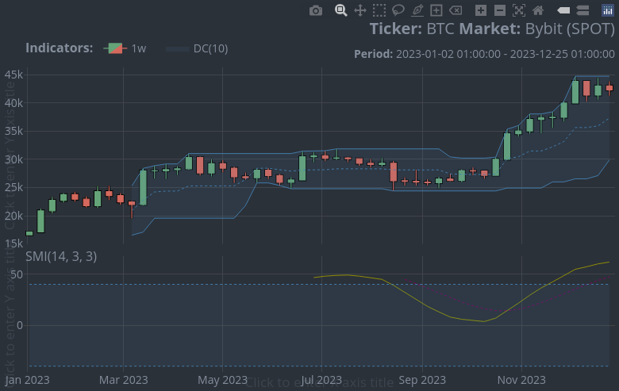

```r
chart(
  ticker = BTC,
  main   = kline(),
  indicator = list(
    donchian_channel()
  ),
  sub = list(
    smi()
  )
)
```

### Expanded Support

- `get_openinterest()` is now supported by `kraken`

**Usage**

```r
tail(
  get_openinterest(
    ticker   = "PF_XBTUSD",
    interval = "1h",
    source   = "kraken"
  )
)
```

```
#>                     open_interest
#> 2024-11-02 04:00:00      2436.653
#> 2024-11-02 05:00:00      2430.302
#> 2024-11-02 06:00:00      2411.765
#> 2024-11-02 07:00:00      2405.188
#> 2024-11-02 08:00:00      2405.124
#> 2024-11-02 09:00:00      2395.924
```

### Charting

- The `chart()`-function now has proper `light`-theme available that isn’t the default `plotly`-values.
- The charts now displays date ranges as a subtitles.
- The `bollinger_bands()`-function now accepts a `color`-argument. These can be passed as `Hexadecimal`-colors or as is, `"blue"` for example.
- A new main chart function has been introduced. `pline()` which is a univariate price chart based on either open, high, low or close prices.

**Usage**

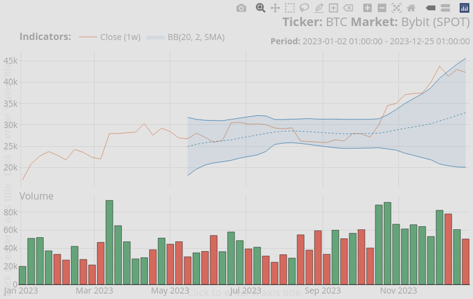

```r
chart(
  ticker = BTC,
  main   = pline(price = "close"),
  indicator = list(
    bollinger_bands(
    color = "steelblue"
  )
  ),
  sub = list(
    volume()
  ),
  options = list(
    dark = FALSE
  )
)
```

### Documentation

- The documentation has been extensively reworked. This is includes, but not limited to, sample outputs for all `get_*`-functions.

### Backend Changes

- The `chart()`-functions no longer depend on `rlang`.

> **Note:** we are generally moving away from `rlang`, `purrr` and `tidyverse` in general. We are, however, keeping the `tidyverse` styleguide.
- Removed dependency on `conflicted`-package.

Prior to version `1.3.0` the `get*`-functions were following the syntax of [{quantmod}](https://github.com/joshuaulrich/quantmod) closely, and this goes for the function naming too. With the adoption of the `tidyverse` style guide, there is no conflicts that needs to be resolved on `stable`- and `experimental`-functions.

### New developper tools

- `pull()`-function
- `var_ly()`-function
- `build()`-function

## Breaking Changes

- The `get_fgindex()`-function now returns columns in lower case.

## Bugfixes

- Fixed a bug where `get_fgindex()` where labelled as `deprecated`
- Fixed a bug in the `limitations`-article where the desired number of observations werent compatible with the `kraken`-exchange.
- Fixed a warning in the `get_lsratio()`-function with `source = "binance"`
- Fixed a bug in the `lsr()`-indicator which broke the `chart()`-function when included.
- Fixed a bug in the `get_quote()`-function where if `to = NULL` and `from != NULL` the returned `quote` would be filtered according to `UTC` and not `Sys.timezone()`
- Fixed a bug in the `chart()`-function where the inferred intervals would be incorrect for leap years, and months different from 30 days.

# Version 1.3.0

## Improvements

### General function improvements

- `get_lsratio` and `getLSratio()` supports `kraken` and `bybit` as `source`
- `available_`-functions are more adaptive to the calling environments

```r
## charting the klines
## with indicators as
## subcharts
available_exchanges(type = 'ohlc')
```

Now returns all available exhanges that supports Open, High, Low and Close market data. The `type`-argument can be changed to, for example, `lsratio` to get all available exchanges that supports Long to Shorts ratios. Similar changes have been made to remaining `available_`-functions.

### Error-handling

All `get_*`- and `available_*`-functions are now more robust to API and input errors.

### Default Returning

- `quotes` and `fear and greed index` now returns `200` rows instead of `100`

### Charting

- The `charts` now has a `dark` and `light` theme. Its passed into the `options = list(dark = TRUE)` of the `chart()`-function.
- The `charts` are now more color deficiency compliant, and the `deficiency` parameter in `options = list(deficiency = TRUE)` now applies to all `chart`-elements
- The `charts` are now constructed without `%>%` and, should, be more intuitive to navigate in. See example below,

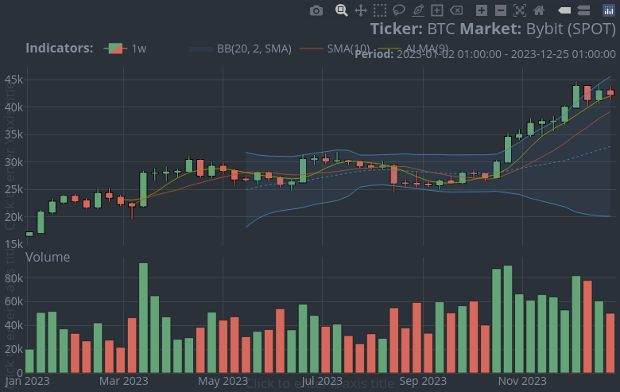

```r
## charting the klines
## with indicators as
## subcharts
chart(
  ticker     = BTC,
  main       = kline(),
  sub        = list(
    volume()
  ),
  indicator = list(
    bollinger_bands(),
    sma(),
    alma()
  ),
  options = list(
    dark       = TRUE,
    deficiency = FALSE
  )
)
```

### Exchange Support

The following exchanges have been added to list of `exchanges` available,

- ByBit

### New features

- Funding rates, `get_fundingrate()`

**Usage**

```r
## get funding rate
tail(
  get_fundingrate(
    ticker = "BTCUSDT",
    source = "binance"
  )
)
```

```
#>                     funding_rate
#> 2024-10-31 17:00:00 1.730390e+12
#> 2024-11-01 01:00:00 1.730419e+12
#> 2024-11-01 09:00:00 1.730448e+12
#> 2024-11-01 17:00:00 1.730477e+12
#> 2024-11-02 01:00:00 1.730506e+12
#> 2024-11-02 09:00:00 1.730534e+12
```

- Open interest, `get_openinterest()`

**Usage**

```r
## get funding rate
tail(
  get_openinterest(
    ticker = "BTCUSDT",
    source = "binance"
  )
)
```

```
#>                     open_interest
#> 2024-10-28 01:00:00      82206.35
#> 2024-10-29 01:00:00      89115.04
#> 2024-10-30 01:00:00      90242.98
#> 2024-10-31 01:00:00      89315.49
#> 2024-11-01 01:00:00      89544.93
#> 2024-11-02 01:00:00      84087.60
```

## Breaking Changes

### Charting

- All the `charting`-functions have been reworked without backwards compatibility, or `lifecycle::deprecated()`-warnings. The `charting`-functions were, and still is, in an `experimental`-stage.

### API Calls

- All `dates` passed to `get_*`-functions assumed the dates were given in `UTC`, and were retrieved as `UTC`. These have now been changed; all functions now uses `Sys.timezone()` as `default` upon request and retrieval.

## Warning

As [{cryptoQuotes}](https://serkor1.github.io/cryptoQuotes/) has moved to the `tidyverse` style guide, the `getFoo`-functions are now `deprecated`. These will be permanently deleted, and removed from the [{cryptoQuotes}](https://serkor1.github.io/cryptoQuotes/), at version 1.4.0!

# Version 1.2.1

### Minor Updates

- Added DOGECOIN data. This data is extracted on the `1m` chart, around Elon Musks Tweet.
- Added a usecase in the Vignette about Dogecoin and Elon Musk to showcase the functionality of the library.

### Bugfixes

- Corrected misspelled ticker in Vignette
- All returned Quotes are now in `UTC`, again.
- Fixed an error on the `Bitmart` API where weekly candles would throw an error.

# Version 1.2.0

- All `from` and `to` arguments are now more flexible, and supports passing `Sys.Date()` and `Sys.time()` directly into the `get`-functions.
- `getQuote()` now returns up to 100 pips preceding the specified `to` date, when `from = NULL`. It returns 100 pips, or up to `Sys.Date()`, from the specified `from` date.

The `getQuote()`-function can now be used as follows;

```r
## Specifying from
## date only;
##
## Returns 10 pips
getQuote(
 ticker   = 'BTCUSDT',
 interval = '1d'
 from     = as.character(Sys.Date() - 10)
 )
```

```r
## Specifying to
## date only;
##
## Returns 100 pips
getQuote(
 ticker   = 'BTCUSDT',
 interval = '1d'
 to     = as.character(Sys.Date())
 )
```

## Market Sentiment

Four new functions are added,

- `getFGIndex()` which returns the daily Fear and Greed Index.
- `addFGIndex()` which adds the Fear and Greed Index as a subplot to price charts.
- `getLSRatio()` which returns the long-short ratio with varying granularity. Contributor has been credited.
- `addLSRatio()` which adds the long-short ratio as a subplot to price charts.

## Convinience functions added

Three new convinience functions are added applicable to some situations,

- `removeBound()`
- `splitWindow()`
- `calibrateWindow()`

# Version 1.1.0

## Frontend

`getQuote()` now returns up to 100 pips when `to` and `from` is `NULL`

## Backend

- All code has been rewritten so its compatible with [{httr2}](https://github.com/r-lib/httr2), the package used [{httr}](https://github.com/r-lib/httr) at version `1.0.0`.

## Future releases

In the next release, three more exchanges will be supported.

## Known bugs

The returned `quotes` are in local timezone, this is an unintentional feature and will be fixed in a bugfix.

# Version 1.0.0

- Initial CRAN submission 🚀